# Robust modelling for dependent biodiversity data: a code-along tutorial

Yefeng Yang, Jinming Pan, David Warton, Shinichi Nakagawa

2026-07-04

Code-along workshop for biodiversity data

Robust modelling, one runnable step at a time

Start with a wetland monitoring dataset, fit a model that is too simple, then repair the analysis piece by piece: ecological structure, residual dependence, site effects, heteroscedasticity, outliers, estimands, robust uncertainty, and prediction checks. The page is designed so a reader can run the chunks in order and always know what question the next model answers.

Runs from a fresh R session Ecology-first interpretation Captions and alt text Advanced code clearly optional

**1. See the pattern**Plot richness, residuals, and lag correlation before trusting a slope.

**2. Add biology**Separate ecological signal from residual dependence.

**3. Model structure**Use GLS, GLMMs, and variance models for the right source of dependence.

**4. Check decisions**Use diagnostics, sensitivity checks, and blocked validation.

# 1 Setup: how to run this tutorial

This tutorial is a code-along page. The core examples use a small set of packages. Advanced examples are shown so that readers can copy and run them after installing the relevant packages.

Render this page from the repository root with:

```r
rmarkdown::render("Script/Expanded_tutorial.Rmd")
```

If a package is missing, the tutorial does one of two things:

- Core code uses base R, `ggplot2`, `nlme`, `glmmTMB`, `sandwich`, `lmtest`, `MASS`, and `sessioninfo` where available.
- Advanced chunks are displayed but skipped if their package is unavailable.

Minimal install for the core tutorial:

```r
install.packages(c(
  "rmarkdown", "knitr", "ggplot2", "nlme", "glmmTMB",
  "sandwich", "lmtest", "MASS", "sessioninfo"
))
```

Full install for optional sections:

```r
install.packages(c(
  "DHARMa", "geepack", "plm", "brms", "clubSandwich"
))
```

On an ordinary laptop, the core examples should render in under a minute after packages are installed. The Bayesian section is intentionally not run by default.

**How to use this page.** If you are new to these models, read the blue workshop box first, run the code chunk immediately below it, and then read the interpretation before moving on. The advanced sections are labelled optional. You can learn the core workflow without installing every package in the matrix.

**Accessibility choices.** Plots have captions and alt text in the rendered HTML. Tables have captions where they carry an interpretation. Colour is used to help scanning, but important contrasts are also described in text, point shape, line position, or table values.

Small glossary for the code-along:

- **Systematic structure**: the biological part of the model, such as effects of temperature, habitat, site, or year.
- **Residual**: what remains after the fitted model has accounted for its systematic structure.
- **Dependence**: shared information among observations, such as repeated surveys from the same site.
- **Autocorrelation**: dependence that changes with distance in time, space, or phylogeny.
- **Estimand**: the quantity the model is trying to estimate, such as a within-site effect or a population-average effect.

**Check package availability on this machine**

This table is useful for troubleshooting, but you do not need to study it before starting the tutorial. The core workflow runs when the core packages are installed; optional packages are skipped or shown without running.

```r
packages <- data.frame(
  package = c(
    "rmarkdown", "knitr", "nlme", "glmmTMB", "sandwich", "lmtest",
    "MASS", "ggplot2", "sessioninfo", "DHARMa", "geepack", "plm", "brms",
    "clubSandwich"
  ),
  role = c(
    "render page", "tables and knitting", "GLS and variance structures",
    "GLMMs and covariance structures", "robust covariance matrices",
    "coefficient tests", "robust regression", "figures", "session information",
    "simulation residual diagnostics", "GEE marginal models",
    "panel fixed-effects models", "Bayesian models",
    "cluster-robust small-sample corrections"
  )
)
packages$installed <- vapply(packages$package, has_pkg, logical(1))
knitr::kable(
  packages,
  caption = "Packages used in the tutorial and whether they are installed on the rendering machine."
)
```

Packages used in the tutorial and whether they are installed on the rendering machine.

| package | role | installed |
| --- | --- | --- |
| rmarkdown | render page | TRUE |
| knitr | tables and knitting | TRUE |
| nlme | GLS and variance structures | TRUE |
| glmmTMB | GLMMs and covariance structures | TRUE |
| sandwich | robust covariance matrices | TRUE |
| lmtest | coefficient tests | TRUE |
| MASS | robust regression | TRUE |
| ggplot2 | figures | TRUE |
| sessioninfo | session information | TRUE |
| DHARMa | simulation residual diagnostics | FALSE |
| geepack | GEE marginal models | FALSE |
| plm | panel fixed-effects models | FALSE |
| brms | Bayesian models | FALSE |
| clubSandwich | cluster-robust small-sample corrections | FALSE |

Minimum learning path:

1. Run setup and build the simulated dataset.
2. Work through Examples 1 to 6.
3. Add Examples 7 to 11 if they match your data problem.
4. Treat Bayesian, real-data, and extension panels as optional next steps.

Core examples in this page are meant to run by default. Optional examples are explicitly labelled and either skipped when packages are missing or shown with `eval = FALSE`.

# 2 Before you use your own data

**Question.** How do I adapt the tutorial to my dataset?

**Plain-English idea.** First map your data columns to the concepts in the tutorial. Then check whether the repeated measurements and time steps match the model you want to fit.

**Run this code.** The chunk below is a template, not code that runs on the simulated data.

**Look at this output.** You want one row per observation, clear site/year identifiers, and no surprise duplicate rows.

**Interpretation.** AR(1) assumes an ordered time variable. Discrete AR(1) examples are easiest when each site has regular time steps.

**Next step.** Rename your columns to the tutorial names, or edit the formulas to match your column names.

**Common mistake.** Do not fit

```
corAR1(form = ~ year |
site)
```

before checking whether years are ordered and whether missing years are meaningful gaps.

```r
# Replace these names with the names in your dataset.
my_data <- data.frame(
  site = your_site_column,
  year = your_year_column,
  richness = your_response_column,
  temp_anomaly = your_temperature_column,
  habitat_quality = your_habitat_column
)

# Basic structure checks.
stopifnot(!anyNA(my_data$site))
stopifnot(!anyNA(my_data$year))
stopifnot(!anyNA(my_data$richness))

# One row per site-year combination?
duplicated_rows <- duplicated(my_data[c("site", "year")])
sum(duplicated_rows)

# How many repeated observations per site?
table(my_data$site)

# Are time steps regular within each site?
time_gaps <- by(my_data$year, my_data$site, function(z) sort(unique(diff(sort(z)))))
time_gaps

# If most sites have gaps larger than one time unit, consider continuous-time
# correlation structures, explicit missing years, or a different validation design.
```

**Source checks.** Package claims in this tutorial were checked against primary or official documentation where possible: [glmmTMB covariance structures](https://cran.r-project.org/package%3DglmmTMB/vignettes/covstruct.html), [nlme manual](https://cran.r-project.org/web/packages/nlme/nlme.pdf), [sandwich vcovCL](https://sandwich.r-forge.r-project.org/reference/vcovCL.html), [DHARMa vignette](https://cran.r-project.org/web/packages/DHARMa/vignettes/DHARMa.html), [brms AR terms](https://paulbuerkner.com/brms/reference/ar.html), and the package pages linked in the capability matrix below.

# 3 The problem: my residuals are autocorrelated

**Question.** I have biodiversity observations collected through time, space, sites, species, or studies. How do I know whether I can treat them as independent?

**Plain-English idea.** Observations can share ecological history. Nearby years, nearby sites, repeated surveys from the same wetland, or related species may be more similar than distant ones.

**Run this code.** We start with a simulated wetland monitoring dataset where the truth is known.

**Look at this output.** The first plot asks whether nearby years look more similar than distant years.

**Interpretation.** Autocorrelation is not a technical nuisance. It is often a biological clue and an uncertainty problem.

**Next step.** Separate the systematic ecological signal from the remaining residual dependence.

**Common mistake.** Do not diagnose autocorrelation in the raw response and immediately add an AR(1) term. First ask whether the pattern is a missing ecological predictor or trend.

The manuscript argues that dependence should be handled by the scientific aim: inference, prediction, or exploration. This tutorial makes that argument practical. We will fit the same ecological story several ways and keep asking: What question does this model answer?

# 4 Signal, distribution, and dependence

**Question.** What do people mean by systematic structure, residuals, and residual dependence?

**Plain-English idea.** A model has a target, such as a mean, a location, a median, or a transformed mean. Dependence is then assessed in what is left over after modelling the target.

**Run this code.** We simulate a tiny 20-year example and draw four panels.

**Look at this output.** The panels show observed data, the systematic component, residuals, and residual dependence.

**Interpretation.** The raw response is not always “mean plus error.” For GLMs, the systematic part often acts through a link function. For robust or quantile models, the target may be a median or another location parameter.

**Next step.** Use this decomposition as a thinking tool, not as a universal equation.

**Common mistake.** Normality is not required for the Gauss-Markov result about least-squares optimality. Normality matters for exact small-sample inference in classical linear models.

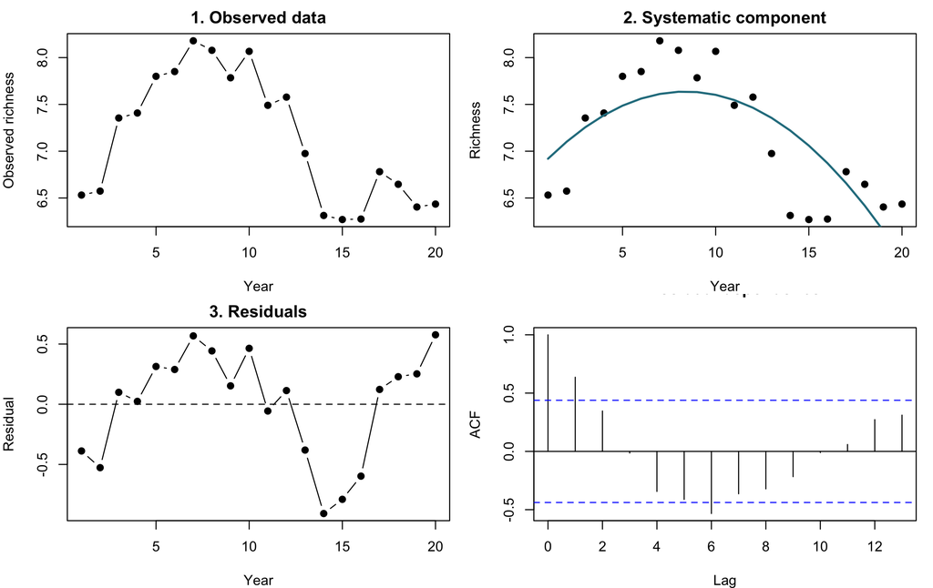

A small teaching example showing observed data, the fitted systematic component, residuals, and residual autocorrelation.

```r
set.seed(13)
tiny_year <- 1:20
tiny_signal <- 6 + 0.25 * tiny_year - 0.012 * tiny_year^2
tiny_resid <- make_ar1(20, phi = 0.75, sigma = 0.35)
tiny_y <- tiny_signal + tiny_resid
tiny_fit <- lm(tiny_y ~ poly(tiny_year, 2, raw = TRUE))
tiny_fitted <- fitted(tiny_fit)
tiny_model_resid <- residuals(tiny_fit)

old_par <- par(mfrow = c(2, 2), mar = c(4, 4, 2, 1))
plot(tiny_year, tiny_y, type = "b", pch = 19,
     xlab = "Year", ylab = "Observed richness", main = "1. Observed data")
plot(tiny_year, tiny_y, pch = 19, xlab = "Year", ylab = "Richness",
     main = "2. Systematic component")
lines(tiny_year, tiny_fitted, col = "#287d8e", lwd = 2)
plot(tiny_year, tiny_model_resid, type = "b", pch = 19,
     xlab = "Year", ylab = "Residual", main = "3. Residuals")
abline(h = 0, lty = 2)
acf(tiny_model_resid, main = "4. Residual dependence")
```

```r
par(old_par)
```

This section addresses the reviewers’ request to replace the overly simple “response = mean + error” framing with a more accurate teaching picture.

# 5 Build the teaching dataset

**Question.** Can we create one ecological example that carries the tutorial?

**Plain-English idea.** We simulate annual species richness across wetland sites. Temperature and habitat quality affect richness. Sites differ in baseline richness. Unmeasured ecological conditions persist through time.

**Run this code.** The code creates `wetland_monitoring`.

**Look at this output.** We inspect rows and plot trajectories.

**Interpretation.** In real data, we do not know the truth. Here we simulate the truth so we can see what each model misses.

**Next step.** Start with a simple model, then add structure deliberately.

**Common mistake.** A realistic simulation is not proof that a method works universally. It is a teaching microscope.

```r
sites <- paste0("W", sprintf("%02d", 1:12))
years <- 2001:2020

wetland_monitoring <- expand.grid(site = sites, year = years)
wetland_monitoring <- wetland_monitoring[
  order(wetland_monitoring$site, wetland_monitoring$year),
]
wetland_monitoring$site <- factor(wetland_monitoring$site)
wetland_monitoring$year_c <- wetland_monitoring$year - mean(years)

annual_temp <- as.numeric(scale(
  seq(-1, 1, length.out = length(years)) +
    make_ar1(length(years), phi = 0.35, sigma = 0.25)
))

site_quality <- rnorm(length(sites), 0, 0.6)
site_effect <- rnorm(length(sites), 0, 2.2)
names(site_quality) <- sites
names(site_effect) <- sites

wetland_monitoring$temp_anomaly <-
  annual_temp[match(wetland_monitoring$year, years)] +
  rnorm(nrow(wetland_monitoring), 0, 0.25)

wetland_monitoring$habitat_quality <-
  site_quality[as.character(wetland_monitoring$site)] -
  0.025 * wetland_monitoring$year_c +
  rnorm(nrow(wetland_monitoring), 0, 0.25)

wetland_monitoring$site_effect <-
  site_effect[as.character(wetland_monitoring$site)]

wetland_monitoring$epsilon_ar1 <- unlist(lapply(
  sites,
  function(z) make_ar1(length(years), phi = 0.70, sigma = 1.1)
))

wetland_monitoring$richness <-
  24 +
  1.7 * wetland_monitoring$temp_anomaly +
  3.8 * wetland_monitoring$habitat_quality -
  0.025 * wetland_monitoring$year_c^2 +
  wetland_monitoring$site_effect +
  wetland_monitoring$epsilon_ar1 +
  rnorm(nrow(wetland_monitoring), 0, 0.35)

wetland_monitoring$richness <- round(pmax(wetland_monitoring$richness, 1), 1)
wetland_monitoring$year_f <- factor(wetland_monitoring$year, levels = years)

knitr::kable(
  head(wetland_monitoring, 10),
  caption = "First ten rows of the simulated wetland monitoring dataset."
)
```

First ten rows of the simulated wetland monitoring dataset.

|  | site | year | year_c | temp_anomaly | habitat_quality | site_effect | epsilon_ar1 | richness | year_f |
| --- | --- | --- | --- | --- | --- | --- | --- | --- | --- |
| 1 | W01 | 2001 | -9.5 | -1.1788012 | 0.0381029 | -0.7678405 | 1.5418401 | 20.5 | 2001 |
| 13 | W01 | 2002 | -8.5 | -0.7526187 | 0.3276322 | -0.7678405 | 2.3130946 | 23.2 | 2002 |
| 25 | W01 | 2003 | -7.5 | -0.8758453 | 0.3470274 | -0.7678405 | 2.7214038 | 24.7 | 2003 |
| 37 | W01 | 2004 | -6.5 | -1.0131858 | 0.5875919 | -0.7678405 | 2.1529357 | 24.8 | 2004 |
| 49 | W01 | 2005 | -5.5 | -0.3636930 | -0.0932322 | -0.7678405 | -0.0713840 | 21.3 | 2005 |
| 61 | W01 | 2006 | -4.5 | -0.5680324 | -0.1660453 | -0.7678405 | 0.2033887 | 21.6 | 2006 |
| 73 | W01 | 2007 | -3.5 | -1.3155380 | 0.4157729 | -0.7678405 | -1.3797506 | 21.6 | 2007 |
| 85 | W01 | 2008 | -2.5 | -1.3755739 | 0.3902048 | -0.7678405 | -1.0421673 | 20.8 | 2008 |
| 97 | W01 | 2009 | -1.5 | -1.0549191 | 0.0560116 | -0.7678405 | -0.3505928 | 21.4 | 2009 |
| 109 | W01 | 2010 | -0.5 | -0.9864985 | 0.3512186 | -0.7678405 | 0.4762251 | 23.5 | 2010 |

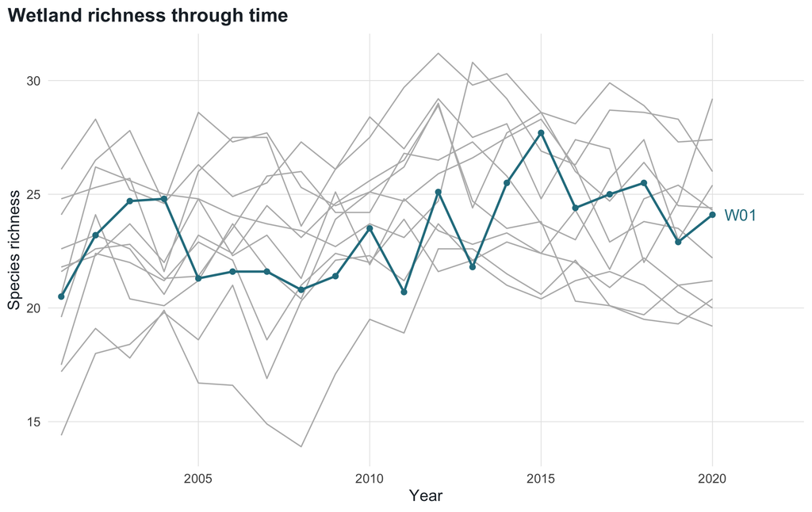

Simulated richness trajectories for 12 wetland sites from 2001 to 2020. The grey lines show all sites, and site W01 is labelled and highlighted only as a reading guide.

```r
site_cols <- grDevices::hcl.colors(length(sites), palette = "Dark 3")
names(site_cols) <- sites

ggplot2::ggplot(wetland_monitoring, ggplot2::aes(year, richness, group = site)) +
  ggplot2::geom_line(colour = site_grey, linewidth = 0.5) +
  ggplot2::geom_line(
    data = subset(wetland_monitoring, site == "W01"),
    colour = site_highlight,
    linewidth = 0.9
  ) +
  ggplot2::geom_point(
    data = subset(wetland_monitoring, site == "W01"),
    colour = site_highlight,
    size = 1.7
  ) +
  ggplot2::annotate(
    "text",
    x = max(wetland_monitoring$year) + 0.35,
    y = subset(wetland_monitoring, site == "W01")$richness[
      nrow(subset(wetland_monitoring, site == "W01"))
    ],
    label = "W01",
    hjust = 0,
    colour = site_highlight
  ) +
  ggplot2::scale_x_continuous(expand = ggplot2::expansion(mult = c(0.02, 0.12))) +
  ggplot2::labs(
    title = "Wetland richness through time",
    x = "Year",
    y = "Species richness"
  ) +
  theme_tutorial()
```

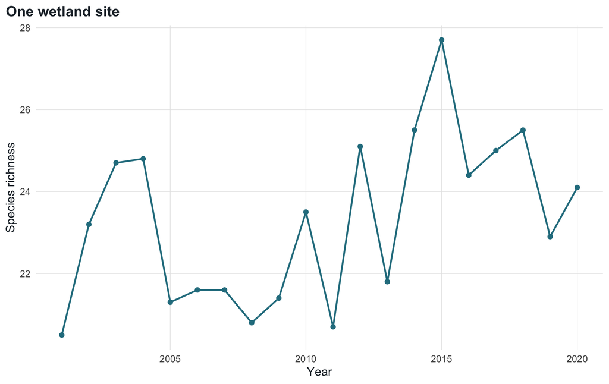

One wetland site shown by itself so the year-to-year pattern is easy to see.

```r
one_site <- subset(wetland_monitoring, site == "W01")
ggplot2::ggplot(one_site, ggplot2::aes(year, richness)) +
  ggplot2::geom_line(colour = site_highlight, linewidth = 0.9) +
  ggplot2::geom_point(colour = site_highlight, size = 2) +
  ggplot2::labs(
    title = "One wetland site",
    x = "Year",
    y = "Species richness"
  ) +
  theme_tutorial()
```

# 6 Example 1: fit a naive model

**Question.** What happens if we fit a simple temperature-richness model and pretend all rows are independent?

**Plain-English idea.** A slope can be estimated even when independence is wrong, but the uncertainty can be too optimistic.

**Run this code.** Fit an ordinary linear model.

**Look at this output.** Inspect the coefficient table and residual autocorrelation.

**Interpretation.** This model estimates a temperature association but ignores habitat, site differences, and temporal memory.

**Next step.** Add plausible ecological structure before treating autocorrelation as a residual problem.

**Common mistake.** A small p-value is not enough if the standard error is wrong.

```r
m_naive <- lm(richness ~ temp_anomaly, data = wetland_monitoring)
knitr::kable(
  tidy_coef(m_naive),
  caption = "Naive linear model that ignores habitat, site differences, and temporal dependence."
)
```

Naive linear model that ignores habitat, site differences, and temporal dependence.

| term | estimate | se | statistic | p_value |
| --- | --- | --- | --- | --- |
| (Intercept) | 23.691 | 0.195 | 121.63 | <0.001 |
| temp_anomaly | 1.026 | 0.195 | 5.27 | <0.001 |

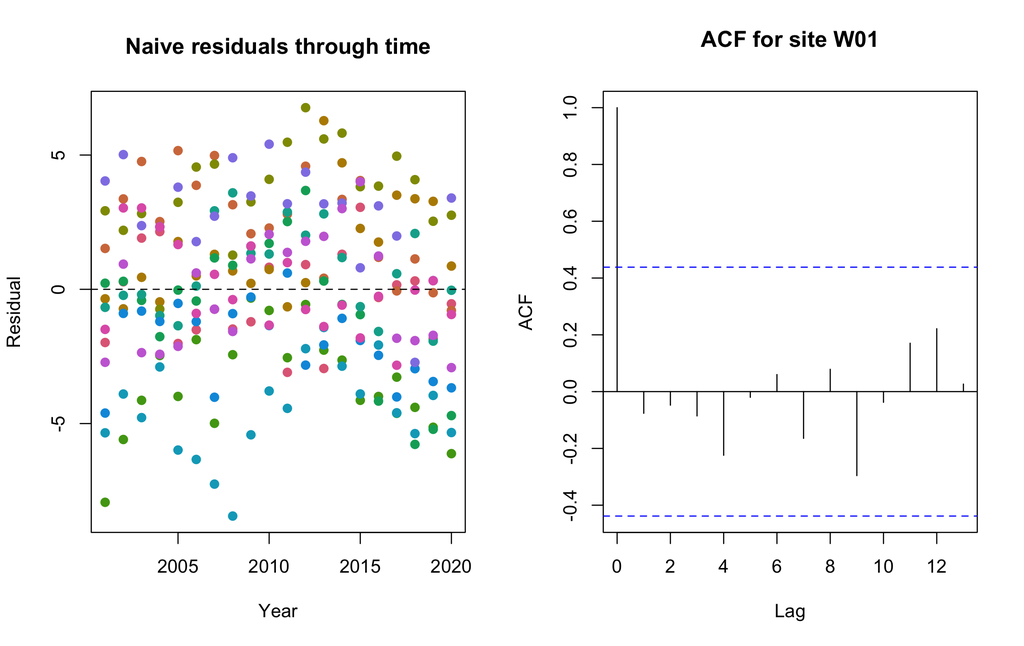

Residual diagnostics for the naive model.

```r
wetland_monitoring$resid_naive <- residuals(m_naive)

old_par <- par(mfrow = c(1, 2))
plot(
  wetland_monitoring$year,
  wetland_monitoring$resid_naive,
  col = site_cols[wetland_monitoring$site],
  pch = 19,
  xlab = "Year",
  ylab = "Residual",
  main = "Naive residuals through time"
)
abline(h = 0, lty = 2)
acf(
  subset(wetland_monitoring, site == "W01")$resid_naive,
  main = "ACF for site W01"
)
```

```r
par(old_par)
```

```r
naive_lag <- lag_cor_by_group(wetland_monitoring, "resid_naive")
knitr::kable(
  round(naive_lag, 3),
  caption = "Within-site residual autocorrelation by lag for the naive model."
)
```

Within-site residual autocorrelation by lag for the naive model.

| lag | mean_autocorrelation | min_site | max_site |
| --- | --- | --- | --- |
| 1 | 0.422 | -0.079 | 0.872 |
| 2 | 0.242 | -0.052 | 0.741 |
| 3 | 0.181 | -0.094 | 0.530 |
| 4 | 0.050 | -0.268 | 0.258 |
| 5 | -0.061 | -0.450 | 0.368 |
| 6 | -0.146 | -0.614 | 0.321 |

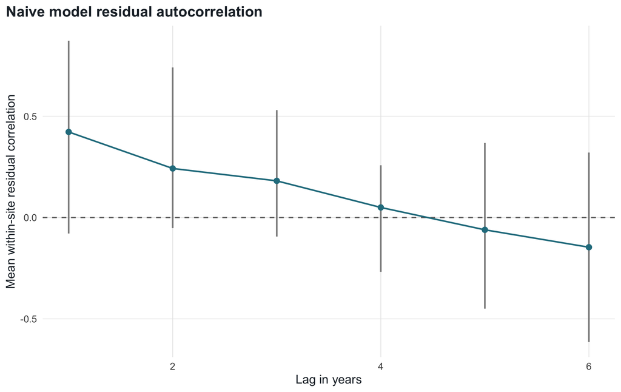

Mean within-site residual autocorrelation for the naive model.

```r
plot_lag_correlation(naive_lag, "Naive model residual autocorrelation")
```

# 7 Example 2: add the systematic structure first

**Question.** Is the apparent dependence really residual autocorrelation, or did we omit ecological structure?

**Plain-English idea.** Autocorrelation should be diagnosed after accounting for plausible biology.

**Run this code.** Add habitat quality and a smooth-enough year trend.

**Look at this output.** Compare the temperature effect and residual lag correlations before and after adding structure.

**Interpretation.** Raw temporal structure can be signal. Adding ecological structure may reduce, change, or reveal residual autocorrelation. What matters is not whether the diagnostic disappears immediately, but whether we now know what remains to model.

**Next step.** If residual autocorrelation remains, model it directly.

**Common mistake.** Do not use an AR(1) term to hide an omitted predictor or an obvious trend.

```r
m_systematic <- lm(
  richness ~ temp_anomaly + habitat_quality + poly(year_c, 2, raw = TRUE),
  data = wetland_monitoring
)
knitr::kable(
  tidy_coef(m_systematic),
  caption = "Linear model after adding habitat quality and a quadratic year trend."
)
```

Linear model after adding habitat quality and a quadratic year trend.

| term | estimate | se | statistic | p_value |
| --- | --- | --- | --- | --- |
| (Intercept) | 24.097 | 0.193 | 125.17 | <0.001 |
| temp_anomaly | 2.226 | 0.264 | 8.44 | <0.001 |
| habitat_quality | 3.186 | 0.179 | 17.83 | <0.001 |
| poly(year_c, 2, raw = TRUE)1 | -0.154 | 0.045 | -3.39 | <0.001 |
| poly(year_c, 2, raw = TRUE)2 | -0.025 | 0.004 | -5.78 | <0.001 |

```r
temp_compare <- rbind(
  extract_term(m_naive, "temp_anomaly", "Naive LM"),
  extract_term(m_systematic, "temp_anomaly", "Systematic LM")
)
knitr::kable(
  temp_compare,
  caption = "Temperature-effect estimate before and after adding systematic ecological structure."
)
```

Temperature-effect estimate before and after adding systematic ecological structure.

| model | estimate | se | statistic | p_value |
| --- | --- | --- | --- | --- |
| Naive LM | 1.026 | 0.195 | 5.27 | <0.001 |
| Systematic LM | 2.226 | 0.264 | 8.44 | <0.001 |

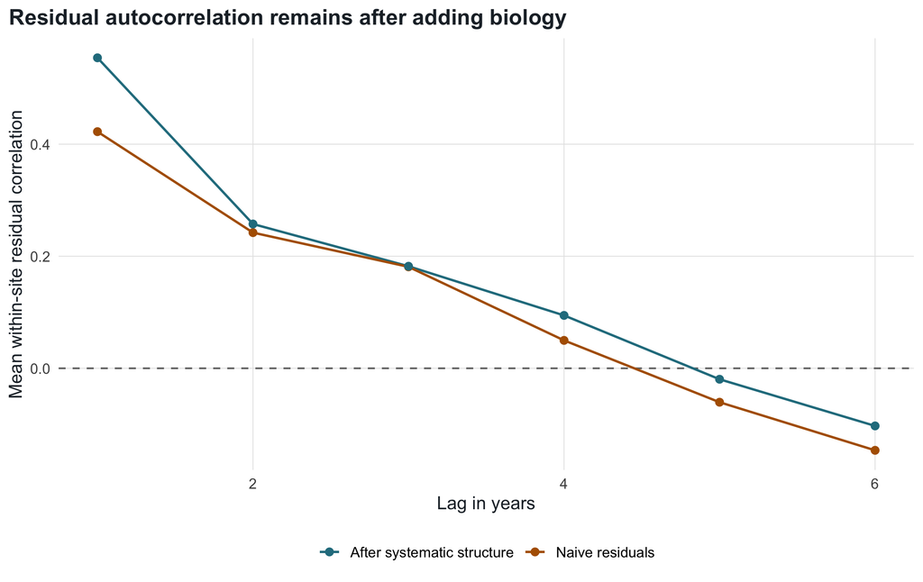

Residual autocorrelation before and after adding systematic ecological structure.

```r
wetland_monitoring$resid_systematic <- residuals(m_systematic)
systematic_lag <- lag_cor_by_group(wetland_monitoring, "resid_systematic")

lag_compare <- rbind(
  data.frame(model = "Naive residuals", naive_lag),
  data.frame(model = "After systematic structure", systematic_lag)
)

ggplot2::ggplot(
  lag_compare,
  ggplot2::aes(x = lag, y = mean_autocorrelation, colour = model)
) +
  ggplot2::geom_hline(yintercept = 0, linetype = "dashed", colour = "grey45") +
  ggplot2::geom_line(linewidth = 0.8) +
  ggplot2::geom_point(size = 2.2) +
  ggplot2::scale_colour_manual(
    values = c("Naive residuals" = warning_colour,
               "After systematic structure" = site_highlight)
  ) +
  ggplot2::labs(
    title = "Residual autocorrelation remains after adding biology",
    x = "Lag in years",
    y = "Mean within-site residual correlation",
    colour = NULL
  ) +
  theme_tutorial()
```

```r
knitr::kable(
  round(systematic_lag, 3),
  caption = "Within-site residual autocorrelation by lag after adding systematic structure."
)
```

Within-site residual autocorrelation by lag after adding systematic structure.

| lag | mean_autocorrelation | min_site | max_site |
| --- | --- | --- | --- |
| 1 | 0.554 | 0.153 | 0.781 |
| 2 | 0.258 | -0.194 | 0.654 |
| 3 | 0.182 | -0.247 | 0.515 |
| 4 | 0.094 | -0.503 | 0.702 |
| 5 | -0.020 | -0.506 | 0.562 |
| 6 | -0.103 | -0.429 | 0.612 |

In this simulated dataset, adding habitat quality and a year trend changes the temperature estimate and clarifies the ecological signal, but it does not remove residual temporal dependence. The lag-1 residual autocorrelation is still about 0.55, so the next step is to model residual temporal dependence directly rather than declare the problem solved.

# 8 Example 3: model residual temporal dependence with GLS

**Question.** What if residuals are still more similar within nearby years after modelling the ecological signal?

**Plain-English idea.** GLS keeps the same systematic component but specifies a residual correlation structure.

**Run this code.** Fit a GLS model with AR(1) residual correlation within each wetland site.

**Look at this output.** Compare the coefficient standard errors and the estimated AR(1) parameter.

**Interpretation.** The biology part is the same, but uncertainty changes because the residual dependence is modelled.

**Next step.** Ask whether the AR(1) structure is biologically plausible and sufficiently supported by the sampling design.

**Common mistake.** Fitting `gls()` without a `correlation =` argument does not model temporal dependence.

```r
m_gls_ar1 <- nlme::gls(
  richness ~ temp_anomaly + habitat_quality + poly(year_c, 2, raw = TRUE),
  correlation = nlme::corAR1(form = ~ year | site),
  data = wetland_monitoring,
  method = "ML"
)

knitr::kable(
  tidy_coef(m_gls_ar1),
  caption = "GLS model with the same systematic terms and AR(1) residual correlation within site."
)
```

GLS model with the same systematic terms and AR(1) residual correlation within site.

| term | estimate | se | statistic | p_value |
| --- | --- | --- | --- | --- |
| (Intercept) | 23.946 | 0.447 | 53.62 | <0.001 |
| temp_anomaly | 1.871 | 0.154 | 12.16 | <0.001 |
| habitat_quality | 3.558 | 0.214 | 16.66 | <0.001 |
| poly(year_c, 2, raw = TRUE)1 | -0.094 | 0.047 | -2.01 | 0.046 |
| poly(year_c, 2, raw = TRUE)2 | -0.022 | 0.006 | -3.72 | <0.001 |

```r
phi_hat <- coef(m_gls_ar1$modelStruct$corStruct, unconstrained = FALSE)
knitr::kable(
  data.frame(parameter = names(phi_hat), estimate = round(as.numeric(phi_hat), 3)),
  caption = "Estimated AR(1) residual correlation parameter from the GLS model."
)
```

Estimated AR(1) residual correlation parameter from the GLS model.

| parameter | estimate |
| --- | --- |
| Phi | 0.808 |

```r
se_compare <- rbind(
  extract_term(m_systematic, "temp_anomaly", "Systematic LM"),
  extract_term(m_gls_ar1, "temp_anomaly", "GLS with AR(1)")
)
knitr::kable(
  se_compare,
  caption = "Temperature-effect comparison between the systematic linear model and GLS AR(1) model."
)
```

Temperature-effect comparison between the systematic linear model and GLS AR(1) model.

| model | estimate | se | statistic | p_value |
| --- | --- | --- | --- | --- |
| Systematic LM | 2.226 | 0.264 | 8.44 | <0.001 |
| GLS with AR(1) | 1.871 | 0.154 | 12.16 | <0.001 |

# 9 Example 4: model site-level dependence

**Question.** How do we handle repeated measurements from the same wetland?

**Plain-English idea.** A random site intercept allows each wetland to have its own baseline richness.

**Run this code.** Fit a Gaussian mixed model with `glmmTMB`.

**Look at this output.** Inspect the fixed effects and the site-level variance component.

**Interpretation.** Persistent differences among sites are not the same as AR(1) residual memory within a site.

**Next step.** Decide whether the main dependence is grouping, temporal memory, or both.

**Common mistake.** A random intercept does not automatically remove residual temporal autocorrelation.

```r
m_site <- glmmTMB::glmmTMB(
  richness ~ temp_anomaly + habitat_quality + poly(year_c, 2, raw = TRUE) +
    (1 | site),
  data = wetland_monitoring
)

knitr::kable(
  tidy_coef(m_site),
  caption = "Mixed model with a site-level random intercept."
)
```

Mixed model with a site-level random intercept.

| term | estimate | se | statistic | p_value |
| --- | --- | --- | --- | --- |
| (Intercept) | 23.986 | 0.401 | 59.75 | <0.001 |
| temp_anomaly | 2.022 | 0.195 | 10.39 | <0.001 |
| habitat_quality | 3.580 | 0.320 | 11.19 | <0.001 |
| poly(year_c, 2, raw = TRUE)1 | -0.115 | 0.034 | -3.39 | <0.001 |
| poly(year_c, 2, raw = TRUE)2 | -0.023 | 0.003 | -7.34 | <0.001 |

```r
summary(m_site)$varcor
```

```
#>
#> Conditional model:
#>  Groups   Name        Std.Dev.
#>  site     (Intercept) 1.2879
#>  Residual             1.3840
```

This connects directly to random-effect syntax in the manuscript’s Table 1: `(1 | site)` means “allow wetland sites to differ in baseline richness.”

# 10 Example 5: combine site structure and temporal dependence

**Question.** Can hierarchical dependence and temporal residual dependence coexist?

**Plain-English idea.** Yes. A site can have a persistent baseline and also show year-to-year residual memory.

**Run this code.** Fit an advanced `glmmTMB` model with a site intercept and AR(1) time structure within site.

**Look at this output.** Inspect the variance components and the AR(1) correlation.

**Interpretation.** This model asks a more detailed question than either random intercepts or AR(1) alone.

**Next step.** Treat this as an advanced candidate in a multiverse, not as the automatic final model.

**Common mistake.** More structure is not always better. Small datasets can overfit complex covariance models.

**Advanced model warning.** The GLS model above is the main residual-correlation teaching example. The `glmmTMB` model below is included because many readers will want to know how site effects and temporal structure can coexist, but it is easier to overfit and harder to diagnose. If the residual standard deviation is near zero, or a variance component looks boundary-like, treat that as a warning to simplify, check sensitivity, and explain the modelling choice.

The current `glmmTMB` covariance-structure vignette uses syntax of the form `ar1(time + 0 | group)`. We use a factor year to represent regularly spaced annual observations within each site.

```r
m_combined <- glmmTMB::glmmTMB(
  richness ~ temp_anomaly + habitat_quality + poly(year_c, 2, raw = TRUE) +
    (1 | site) + ar1(0 + year_f | site),
  data = wetland_monitoring
)

knitr::kable(
  tidy_coef(m_combined),
  caption = "Mixed model with site-level baseline differences and within-site AR(1) temporal dependence."
)
```

Mixed model with site-level baseline differences and within-site AR(1) temporal dependence.

| term | estimate | se | statistic | p_value |
| --- | --- | --- | --- | --- |
| (Intercept) | 23.948 | 0.463 | 51.68 | <0.001 |
| temp_anomaly | 1.875 | 0.154 | 12.21 | <0.001 |
| habitat_quality | 3.576 | 0.224 | 15.97 | <0.001 |
| poly(year_c, 2, raw = TRUE)1 | -0.094 | 0.038 | -2.51 | 0.012 |
| poly(year_c, 2, raw = TRUE)2 | -0.022 | 0.005 | -4.63 | <0.001 |

```r
summary(m_combined)$varcor
```

```
#>
#> Conditional model:
#>  Groups   Name        Std.Dev.   Corr
#>  site     (Intercept) 1.23618708
#>  site.1   year_f2001  1.52122408 0.684 (ar1)
#>  Residual             0.00031894
```

In `glmmTMB` output, the AR(1) term may appear as a variance component with a label such as `site.1 year_f2001` and a correlation line marked `(ar1)`. That label means the model has created a structured time effect within each site; it does not mean that only the year 2001 was modelled. A very small residual standard deviation can also appear when much of the remaining within-site variation has been allocated to the structured AR(1) term. In practice, that is a prompt for a sensitivity check, not a victory lap.

If this model fails or is unstable in a reader’s dataset, the safer teaching move is to return to the GLS AR(1) example and then add complexity one piece at a time.

# 11 Example 6: read diagnostics without worshipping p-values

**Question.** How should we use residual plots and diagnostic tests?

**Plain-English idea.** Diagnostics are warnings and guides, not automatic model selectors.

**Run this code.** Plot residuals against fitted values, time, and lag.

**Look at this output.** Ask whether structure remains large enough to matter for the scientific question.

**Interpretation.** A tiny diagnostic p-value in a large dataset may not matter biologically. A visible pattern in a small dataset may matter even without a tiny p-value.

**Next step.** Combine plots, effect sizes, model purpose, and ecological plausibility.

**Common mistake.** Do not keep adding terms until every diagnostic test is non-significant.

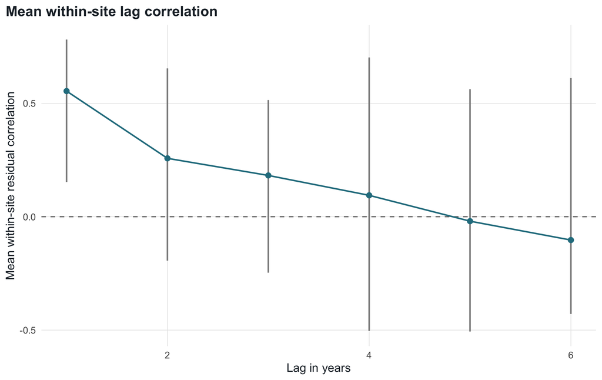

```r
old_par <- par(mfrow = c(2, 2))
plot(fitted(m_systematic), residuals(m_systematic),
     xlab = "Fitted value", ylab = "Residual",
     main = "Systematic LM residuals")
abline(h = 0, lty = 2)
plot(wetland_monitoring$year, residuals(m_systematic),
     col = site_cols[wetland_monitoring$site], pch = 19,
     xlab = "Year", ylab = "Residual",
     main = "Residuals through time")
abline(h = 0, lty = 2)
acf(subset(wetland_monitoring, site == "W01")$resid_systematic,
    main = "ACF for one site")
plot_lag_correlation(systematic_lag, "Mean within-site lag correlation")
par(old_par)
```

**Not run on this machine:** the `DHARMa` package is not installed. The code is shown so readers can run it after installing the package.

```r
sim_res <- DHARMa::simulateResiduals(m_combined)
plot(sim_res)
DHARMa::testTemporalAutocorrelation(
  sim_res,
  time = wetland_monitoring$year
)
```

DHARMa includes tests for temporal, spatial, and phylogenetic autocorrelation in simulation residuals, but the right test still depends on the structure supplied by the analyst. A temporal test is not evidence about a phylogenetic covariance matrix, and a spatial test needs the right spatial coordinates or distance matrix.

# 12 Example 7: heteroscedasticity

**Question.** What if residual variance changes with environmental stress?

**Plain-English idea.** Variance can be biological. A stressful environment may make richness less predictable.

**Run this code.** Create data where residual spread increases with temperature anomaly and fit a variance model.

**Look at this output.** Compare residual plots and GLS weights.

**Interpretation.** Heteroscedasticity mainly affects uncertainty, but changing variance can also be ecologically meaningful.

**Next step.** Choose a variance structure that matches the predictor scale.

**Common mistake.**

```
varIdent(form = ~ 1 |
group)
```

is for categorical groups. For a continuous variance covariate, use structures such as `varPower()` or `varExp()`.

```r
set.seed(2027)
dat_het <- wetland_monitoring
dat_het$temp_abs <- abs(dat_het$temp_anomaly) + 0.2

mu_het <-
  24 +
  1.7 * dat_het$temp_anomaly +
  3.8 * dat_het$habitat_quality -
  0.025 * dat_het$year_c^2 +
  dat_het$site_effect

sigma_het <- 0.5 + 1.1 * dat_het$temp_abs
dat_het$richness <- round(pmax(mu_het + rnorm(nrow(dat_het), 0, sigma_het), 1), 1)

m_het_naive <- lm(richness ~ temp_anomaly, data = dat_het)
m_het_gls <- nlme::gls(
  richness ~ temp_anomaly,
  weights = nlme::varPower(form = ~ temp_abs),
  data = dat_het,
  method = "ML"
)

knitr::kable(
  tidy_coef(m_het_naive),
  caption = "Naive linear model for the heteroscedastic dataset."
)
```

Naive linear model for the heteroscedastic dataset.

| term | estimate | se | statistic | p_value |
| --- | --- | --- | --- | --- |
| (Intercept) | 23.432 | 0.202 | 116.28 | <0.001 |
| temp_anomaly | 1.097 | 0.201 | 5.45 | <0.001 |

```r
knitr::kable(
  tidy_coef(m_het_gls),
  caption = "GLS model with residual variance changing with temperature anomaly."
)
```

GLS model with residual variance changing with temperature anomaly.

| term | estimate | se | statistic | p_value |
| --- | --- | --- | --- | --- |
| (Intercept) | 23.556 | 0.196 | 119.98 | <0.001 |
| temp_anomaly | 1.121 | 0.214 | 5.24 | <0.001 |

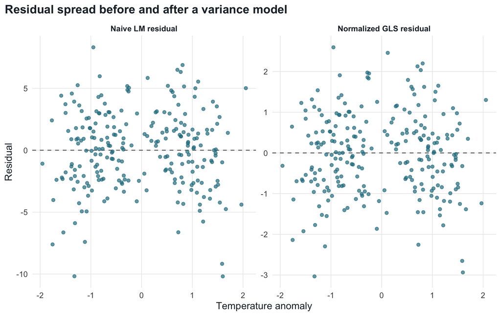

Residual spread before and after modelling heteroscedasticity.

```r
het_plot_data <- rbind(
  data.frame(
    temp_anomaly = dat_het$temp_anomaly,
    residual = residuals(m_het_naive),
    model = "Naive LM residual"
  ),
  data.frame(
    temp_anomaly = dat_het$temp_anomaly,
    residual = residuals(m_het_gls, type = "normalized"),
    model = "Normalized GLS residual"
  )
)

ggplot2::ggplot(het_plot_data, ggplot2::aes(temp_anomaly, residual)) +
  ggplot2::geom_hline(yintercept = 0, linetype = "dashed", colour = "grey45") +
  ggplot2::geom_point(alpha = 0.7, colour = site_highlight, size = 1.7) +
  ggplot2::facet_wrap(~ model, nrow = 1, scales = "free_y") +
  ggplot2::labs(
    x = "Temperature anomaly",
    y = "Residual",
    title = "Residual spread before and after a variance model"
  ) +
  theme_tutorial()
```

This is the practical counterpart of Box 2 in the manuscript.

# 13 Example 8: outliers and robustness

**Question.** What should we do with extreme years or extreme sites?

**Plain-English idea.** Outliers may be data errors, rare ecological events, or signs that the model is too simple.

**Run this code.** Add a few extreme observations and compare ordinary and robust fits.

**Look at this output.** Inspect the fitted slope and residual plot.

**Interpretation.** A sensitivity analysis is usually better than automatic deletion.

**Next step.** Report whether the scientific conclusion depends on the extreme observations.

**Common mistake.** Do not delete biologically real extremes just because they make the model uncomfortable.

```r
set.seed(2028)
dat_outlier <- wetland_monitoring
outlier_rows <- sample(seq_len(nrow(dat_outlier)), 5)
dat_outlier$richness[outlier_rows] <- dat_outlier$richness[outlier_rows] +
  sample(c(-9, 10, 12), length(outlier_rows), replace = TRUE)
dat_outlier$outlier_added <- seq_len(nrow(dat_outlier)) %in% outlier_rows

m_out_lm <- lm(richness ~ temp_anomaly + habitat_quality, data = dat_outlier)
m_out_robust <- MASS::rlm(richness ~ temp_anomaly + habitat_quality,
                          data = dat_outlier)

outlier_compare <- rbind(
  extract_term(m_out_lm, "temp_anomaly", "Ordinary LM"),
  data.frame(
    model = "Robust regression (MASS::rlm)",
    estimate = round(coef(m_out_robust)["temp_anomaly"], 3),
    se = NA_real_,
    statistic = NA_real_,
    p_value = NA_character_
  )
)
knitr::kable(
  outlier_compare,
  caption = "Sensitivity of the temperature-effect estimate to ordinary versus robust regression."
)
```

Sensitivity of the temperature-effect estimate to ordinary versus robust regression.

|  | model | estimate | se | statistic | p_value |
| --- | --- | --- | --- | --- | --- |
| 1 | Ordinary LM | 1.456 | 0.159 | 9.18 | <0.001 |
| temp_anomaly | Robust regression (MASS::rlm) | 1.363 | NA | NA | NA |

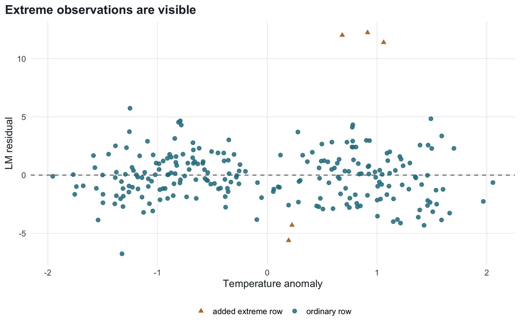

Residual plot with added extreme observations marked by triangles.

```r
dat_outlier$resid_lm <- residuals(m_out_lm)
dat_outlier$outlier_label <- ifelse(dat_outlier$outlier_added,
                                    "added extreme row", "ordinary row")

ggplot2::ggplot(dat_outlier, ggplot2::aes(temp_anomaly, resid_lm)) +
  ggplot2::geom_hline(yintercept = 0, linetype = "dashed", colour = "grey45") +
  ggplot2::geom_point(
    ggplot2::aes(shape = outlier_label, colour = outlier_label),
    size = 2,
    alpha = 0.85
  ) +
  ggplot2::scale_shape_manual(values = c("added extreme row" = 17,
                                         "ordinary row" = 19)) +
  ggplot2::scale_colour_manual(values = c("added extreme row" = warning_colour,
                                          "ordinary row" = site_highlight)) +
  ggplot2::labs(
    title = "Extreme observations are visible",
    x = "Temperature anomaly",
    y = "LM residual",
    shape = NULL,
    colour = NULL
  ) +
  theme_tutorial()
```

# 14 Example 9: conditional, marginal, and within-site effects

**Question.** Are GLMMs, GEEs, and fixed-effects models just different software for the same question?

**Plain-English idea.** No. They can target different estimands.

**Run this code.** Decompose temperature into a within-site part and a between-site part, then compare the question each coefficient answers.

**Look at this output.** Focus on the interpretation of the temperature effect, not only the number.

**Interpretation.** Conditional means “within a site, after accounting for site baseline.” Marginal means “average across the population of sites.” Within-site means “when a site is warmer than its own average.” Between-site means “sites that are warmer on average than other sites.”

**Next step.** State the estimand before choosing software.

**Common mistake.** Do not call a difference among estimands a robustness failure unless the models are meant to answer the same question.

```r
dat_within <- wetland_monitoring
dat_within$temp_site_mean <- ave(dat_within$temp_anomaly, dat_within$site)
dat_within$temp_within <- dat_within$temp_anomaly - dat_within$temp_site_mean

m_population <- lm(
  richness ~ temp_anomaly + habitat_quality + poly(year_c, 2, raw = TRUE),
  data = dat_within
)

m_within_between <- lm(
  richness ~ temp_within + temp_site_mean + habitat_quality +
    poly(year_c, 2, raw = TRUE),
  data = dat_within
)

estimand_compare <- rbind(
  extract_term(m_population, "temp_anomaly", "Pooled temperature effect"),
  extract_term(m_within_between, "temp_within", "Within-site temperature effect"),
  extract_term(m_within_between, "temp_site_mean", "Between-site temperature contrast")
)

knitr::kable(
  estimand_compare,
  caption = "A within-between decomposition separates different temperature estimands."
)
```

A within-between decomposition separates different temperature estimands.

| model | estimate | se | statistic | p_value |
| --- | --- | --- | --- | --- |
| Pooled temperature effect | 2.226 | 0.264 | 8.44 | <0.001 |
| Within-site temperature effect | 2.014 | 0.241 | 8.35 | <0.001 |
| Between-site temperature contrast | 16.077 | 1.956 | 8.22 | <0.001 |

The pooled temperature coefficient mixes two questions: what happens when a site is warmer than usual, and how warmer sites differ from cooler sites. The within-between decomposition separates these. This is often called a Mundlak-style decomposition in panel-data discussions.

```r
m_conditional_mundlak <- glmmTMB::glmmTMB(
  richness ~ temp_within + temp_site_mean + habitat_quality +
    poly(year_c, 2, raw = TRUE) + (1 | site),
  data = dat_within
)

cond_terms <- tidy_coef(m_conditional_mundlak)
cond_terms <- cond_terms[
  cond_terms$term %in% c("temp_within", "temp_site_mean", "habitat_quality"),
]

knitr::kable(
  cond_terms,
  caption = "Conditional mixed model with within-site and between-site temperature terms."
)
```

Conditional mixed model with within-site and between-site temperature terms.

|  | term | estimate | se | statistic | p_value |
| --- | --- | --- | --- | --- | --- |
| 2 | temp_within | 2.010 | 0.195 | 10.32 | <0.001 |
| 3 | temp_site_mean | 16.345 | 5.295 | 3.09 | 0.002 |
| 4 | habitat_quality | 3.554 | 0.297 | 11.98 | <0.001 |

The conditional mixed model asks about temperature after allowing wetland sites to differ in baseline richness. The within-site term is usually closest to the question “what happens when this site is warmer than its own average?”

**Not run on this machine:** the `geepack` package is not installed. The code is shown so readers can run it after installing the package.

```r
m_gee <- geepack::geeglm(
  richness ~ temp_within + temp_site_mean + habitat_quality +
    poly(year_c, 2, raw = TRUE),
  id = site,
  waves = year,
  corstr = "ar1",
  data = dat_within
)
summary(m_gee)
```

**Not run on this machine:** the `plm` package is not installed. The code is shown so readers can run it after installing the package.

```r
m_plm <- plm::plm(
  richness ~ temp_anomaly + habitat_quality + poly(year_c, 2, raw = TRUE),
  data = dat_within,
  index = c("site", "year"),
  model = "within"
)
summary(m_plm)
```

# 15 Example 10: robust standard errors

**Question.** What if we want inference that is less sensitive to within-site correlation?

**Plain-English idea.** Cluster-robust standard errors adjust uncertainty. They do not change the ecological model.

**Run this code.** Fit a simple linear model and compute site-clustered standard errors.

**Look at this output.** Compare ordinary and cluster-robust standard errors.

**Interpretation.** Robust SEs can protect inference when the dependence model is uncertain, but the cluster definition must match the sampling process.

**Next step.** Use enough independent clusters, report the clustering level, and prefer small-sample corrections such as CR2 when available.

**Common mistake.** Robust SEs do not fix a missing predictor, an inappropriate response distribution, or a biased sampling design.

```r
m_lm_cluster <- lm(
  richness ~ temp_anomaly + habitat_quality,
  data = wetland_monitoring
)

ordinary <- tidy_coef(m_lm_cluster)
n_site_clusters <- length(unique(wetland_monitoring$site))
V_cluster <- sandwich::vcovCL(
  m_lm_cluster,
  cluster = wetland_monitoring$site,
  type = "HC1"
)
clustered <- lmtest::coeftest(m_lm_cluster, vcov. = V_cluster)
clustered <- data.frame(
  term = rownames(clustered),
  estimate = round(clustered[, 1], 3),
  se = round(clustered[, 2], 3),
  statistic = round(clustered[, 3], 2),
  p_value = format_p(clustered[, 4]),
  row.names = NULL
)

ordinary$model <- "ordinary LM SE"
clustered$model <- "site-clustered SE"
robust_compare <- rbind(ordinary, clustered)
robust_compare <- robust_compare[
  robust_compare$term %in% c("temp_anomaly", "habitat_quality"),
  c("model", "term", "estimate", "se", "statistic", "p_value")
]
knitr::kable(
  robust_compare,
  caption = paste(
    "Ordinary standard errors versus illustrative site-clustered robust standard errors.",
    "There are", n_site_clusters, "site clusters."
  )
)
```

Ordinary standard errors versus illustrative site-clustered robust standard errors. There are 12 site clusters.

|  | model | term | estimate | se | statistic | p_value |
| --- | --- | --- | --- | --- | --- | --- |
| 2 | ordinary LM SE | temp_anomaly | 1.351 | 0.132 | 10.24 | <0.001 |
| 3 | ordinary LM SE | habitat_quality | 3.261 | 0.191 | 17.09 | <0.001 |
| 5 | site-clustered SE | temp_anomaly | 1.351 | 0.192 | 7.04 | <0.001 |
| 6 | site-clustered SE | habitat_quality | 3.261 | 0.450 | 7.25 | <0.001 |

With only 12 site clusters, the HC1 cluster-robust standard errors above are a teaching example, not a gold-standard final analysis. For a paper, prefer a small-sample correction such as CR2 with Satterthwaite degrees of freedom when `clubSandwich` supports the fitted model.

**Not run on this machine:** the `clubSandwich` package is not installed. The code is shown so readers can run it after installing the package.

```r
clubSandwich::coef_test(
  m_lm_cluster,
  vcov = "CR2",
  cluster = wetland_monitoring$site,
  test = "Satterthwaite"
)
```

# 16 Example 11: prediction and data leakage

**Question.** Why can random cross-validation be too optimistic for dependent biodiversity data?

**Plain-English idea.** If training and test data share nearby years or the same sites, the test set is not truly independent for the prediction task.

**Run this code.** Compare random, future-year, and new-site holdouts.

**Look at this output.** The RMSE changes because the prediction task changes.

**Interpretation.** To predict future years, hold out future years. To predict new sites, hold out sites. To predict new species or clades, hold out species or clades.

**Next step.** Design validation around the deployment problem.

**Common mistake.** Random row splits can leak spatial, temporal, phylogenetic, or hierarchical information into the test set.

```r
set.seed(2029)

random_test <- sample(seq_len(nrow(wetland_monitoring)),
                      size = floor(0.25 * nrow(wetland_monitoring)))
future_test <- wetland_monitoring$year >= 2017
site_test <- wetland_monitoring$site %in% sample(levels(wetland_monitoring$site), 3)

split_results <- list(
  random_rows = list(train = !seq_len(nrow(wetland_monitoring)) %in% random_test,
                     test = seq_len(nrow(wetland_monitoring)) %in% random_test),
  future_years = list(train = !future_test, test = future_test),
  new_sites = list(train = !site_test, test = site_test)
)

cv_results <- lapply(names(split_results), function(nm) {
  idx <- split_results[[nm]]
  train <- wetland_monitoring[idx$train, ]
  test <- wetland_monitoring[idx$test, ]
  pred <- fit_lm_predict(train, test)
  data.frame(
    validation = nm,
    n_train = nrow(train),
    n_test = nrow(test),
    rmse = round(rmse(test$richness, pred), 3)
  )
})

knitr::kable(
  do.call(rbind, cv_results),
  caption = "Prediction error under random-row, future-year, and new-site validation."
)
```

Prediction error under random-row, future-year, and new-site validation.

| validation | n_train | n_test | rmse |
| --- | --- | --- | --- |
| random_rows | 180 | 60 | 1.848 |
| future_years | 192 | 48 | 1.983 |
| new_sites | 180 | 60 | 1.850 |

# 17 Optional Bayesian example

**Question.** Do Bayesian models remove the need to think about autocorrelation?

**Plain-English idea.** No. Bayesian models can include dependence structures and priors, but dependence still has to be represented in the model.

**Run this code.** The chunk is not run by default because Bayesian fitting can be slow and requires `brms` and Stan tooling.

**Look at this output.** In a real analysis, inspect posterior intervals, posterior predictive checks, and convergence diagnostics.

**Interpretation.** Priors can regularize complex models, but they are not a substitute for the sampling design or residual checks.

**Next step.** Use Bayesian models when posterior uncertainty, partial pooling, prior information, or complex covariance structures matter for the question.

**Common mistake.** Do not say “we used Bayesian methods” as if that automatically handles dependence.

**Shown but not run by default:** Bayesian examples can take minutes to hours and require `brms` plus Stan tooling. The code below is visible for readers who want to run it deliberately.

**Not run on this machine:** the `brms` package is not installed. The code is shown so readers can run it after installing the package.

```r
m_bayes_ar1 <- brms::brm(
  brms::bf(
    richness ~ temp_anomaly + habitat_quality + poly(year_c, 2, raw = TRUE) +
      (1 | site) + brms::ar(time = year, gr = site, p = 1)
  ),
  data = wetland_monitoring,
  family = gaussian(),
  prior = c(
    brms::prior(normal(0, 2), class = "b"),
    brms::prior(exponential(1), class = "sd"),
    brms::prior(exponential(1), class = "sigma")
  ),
  chains = 4,
  iter = 2000,
  cores = 4
)
```

For phylogenetic models in `brms`, the pattern is to pass a known covariance matrix with `gr(species, cov = A)` and `data2 = list(A = A)`.

```r
m_bayes_phylo <- brms::brm(
  trait ~ predictor + (1 | brms::gr(species, cov = A)),
  data = comparative_data,
  data2 = list(A = phylogenetic_covariance_matrix),
  family = gaussian()
)
```

# 18 Optional real ecological data sidebar

**Question.** Can we see a real ecological count-data example?

**Plain-English idea.** The core tutorial uses simulation because the truth is known. A real dataset is useful for seeing non-normal responses and site-level structure.

**Run this code.** Use `glmmTMB::Salamanders` if `glmmTMB` is installed.

**Look at this output.** Fit a negative-binomial model for counts with site-level random effects and zero inflation.

**Interpretation.** This is a count-data sidebar, not the core autocorrelation example.

**Next step.** Cite the package and the data source when using this dataset.

**Common mistake.** Do not treat a convenient package dataset as if it has the same sampling structure as your own monitoring data.

The `Salamanders` documentation describes repeated counts from 23 stream sites sampled four times. The documentation asks users to cite Price et al. (2016) and the Dryad data package Price et al. (2015, DOI `10.5061/dryad.5m8f6`) as well as `glmmTMB` when using the dataset.

```r
data("Salamanders", package = "glmmTMB")
salamanders <- glmmTMB::Salamanders
knitr::kable(
  head(salamanders, 8),
  caption = "First rows of the glmmTMB Salamanders dataset."
)
```

First rows of the glmmTMB Salamanders dataset.

| site | mined | cover | sample | DOP | Wtemp | DOY | spp | count |
| --- | --- | --- | --- | --- | --- | --- | --- | --- |
| VF-1 | yes | -1.4423172 | 1 | -0.5956834 | -1.2293786 | -1.4970025 | GP | 0 |
| VF-2 | yes | 0.2984104 | 1 | -0.5956834 | 0.0847653 | -1.4970025 | GP | 0 |
| VF-3 | yes | 0.3978806 | 1 | -1.1913668 | 1.0141763 | -1.2944669 | GP | 0 |
| R-1 | no | -0.4476157 | 1 | 0.0000000 | -3.0233580 | -2.7122163 | GP | 2 |
| R-2 | no | 0.5968209 | 1 | 0.5956834 | -0.1443453 | -0.6868600 | GP | 2 |
| R-3 | no | 1.3428470 | 1 | 0.5956834 | -0.0146601 | -0.6868600 | GP | 1 |
| R-4 | no | -0.9449664 | 1 | -0.5956834 | -0.4469442 | -0.9704099 | GP | 1 |
| R-5 | no | 0.4973508 | 1 | -0.5956834 | -0.6025666 | -0.9704099 | GP | 2 |

```r
m_salamanders <- glmmTMB::glmmTMB(
  count ~ mined + (1 | site),
  ziformula = ~ mined,
  family = glmmTMB::nbinom2,
  data = salamanders
)

knitr::kable(
  tidy_coef(m_salamanders),
  caption = "Negative-binomial count model for the Salamanders sidebar."
)
```

Negative-binomial count model for the Salamanders sidebar.

| term | estimate | se | statistic | p_value |
| --- | --- | --- | --- | --- |
| (Intercept) | -0.557 | 0.371 | -1.50 | 0.133 |
| minedno | 1.467 | 0.362 | 4.06 | <0.001 |

# 19 Extension panels: when the core tutorial is not enough

The core examples teach the workflow. The next panels help readers choose the right next tool when their data have stronger structure than this tutorial can fit in a short web page.

## 19.1 Spatial GLMMs

Use these when observations are linked by geographic distance or spatial fields. Packages include `sdmTMB`, `INLA`, `spaMM`, and `glmmTMB`.

```r
mesh <- sdmTMB::make_mesh(dat, xy_cols = c("x", "y"), cutoff = 10)
m_spatial <- sdmTMB::sdmTMB(
  count ~ habitat + depth,
  data = dat,
  mesh = mesh,
  family = nbinom2(),
  spatial = "on",
  spatiotemporal = "ar1",
  time = "year"
)
```

Caveat: distance-based spatial models often assume a particular covariance shape. Check stationarity, anisotropy, boundaries, and the scale of sampling.

## 19.2 Stream networks

Use these for rivers and streams where flow connectivity matters. Stream sites can be close in Euclidean distance but disconnected by flow.

```r
m_stream <- SSN2::ssn_lm(
  richness ~ temperature + canopy,
  ssn.object = stream_network_object,
  tailup_type = "exponential",
  additive = "afvArea"
)
```

Caveat: this is not ordinary two-dimensional spatial autocorrelation. Directional flow and branching structure are part of the model.

## 19.3 Lattice SAR/CAR models

Use these when dependence is defined by neighbours among areas, polygons, or network nodes rather than by continuous distance.

```r
m_bym2 <- INLA::inla(
  count ~ habitat + f(area_id, model = "bym2", graph = adjacency_graph),
  family = "poisson",
  data = area_data
)
```

Caveat: adjacency models answer an areal-neighbour question. They are not automatically appropriate for point-referenced observations.

## 19.4 Phylogenetic dependence

Use these when species share evolutionary history.

```r
A <- ape::vcv.phylo(tree, corr = TRUE)
m_phylo <- brms::brm(
  trait ~ environment + (1 | brms::gr(species, cov = A)),
  data = trait_data,
  data2 = list(A = A),
  family = gaussian()
)
```

Caveat: the tree, branch lengths, and evolutionary model are assumptions, not decoration.

## 19.5 Community and JSDM models

Use these when many species are modelled together and residual association among species is part of the question.

```r
m_gllvm <- gllvm::gllvm(
  y = species_matrix,
  X = environmental_data,
  family = "negative.binomial",
  num.lv = 2,
  method = "VA"
)
```

Caveat: latent variables can reveal residual structure, but they need careful interpretation and diagnostics.

## 19.6 Big spatial and spatio-temporal data

Use these when the dataset is too large for dense covariance matrices or needs spatio-temporal prediction.

```r
m_frk <- FRK::SRE(
  f = z ~ covariate,
  data = spatial_data,
  basis = FRK::auto_basis(manifold = FRK::plane(), data = spatial_data)
)
```

Caveat: reduced-rank or basis-function models trade exact covariance detail for scalability and prediction.

## 19.7 Genomic or relationship matrices

Use these when the covariance among levels is known or estimated from pedigree, genomic, or other relationship matrices.

```r
m_sommer <- sommer::mmer(
  trait ~ environment,
  random = ~ sommer::vsr(species, Gu = relationship_matrix),
  data = trait_data
)
```

Caveat: dense covariance problems can become computationally difficult, and the relationship matrix must be biologically defensible.

# 20 Package capability matrix

These tables are a map, not a ranking. Beginner suitability refers to first use by an applied ecologist, not to the quality of the package. The information is split into narrower tables so it is easier to read on small screens and with screen readers.

Start here before reading the tables:

- Repeated measurements from plots, sites, studies, observers, or species: start with `lme4`, `glmmTMB`, or `nlme`.
- Gaussian residual autocorrelation through time within sites: start with `nlme::gls()` and `corAR1()`.
- Non-Gaussian counts, presence-absence data, or zero inflation: start with `glmmTMB`, then add structure cautiously.
- Population-average effects from clustered data: consider `geepack`, but state that the estimand is marginal.
- Uncertain correlation but many independent clusters: consider robust standard errors, preferably with small-sample corrections.
- Spatial fields, streams, phylogenies, or multivariate communities: go to the relevant extension panel first, then choose software.

```r
link <- function(text, url) {
  sprintf("<a href='%s'>%s</a>", url, text)
}

pkg_matrix <- data.frame(
  problem = c(
    "Gaussian repeated measures", "GLMMs and covariance structures",
    "Hierarchical LMMs/GLMMs", "Bayesian multilevel dependence",
    "Marginal correlated data", "Within-unit panel effects",
    "Robust covariance", "Cluster-robust small-sample inference",
    "Simulation residual diagnostics", "Smooth temporal/spatial signal",
    "Stream-network dependence", "Spatial/spatio-temporal GLMMs",
    "Large spatial/spatio-temporal prediction", "Latent Gaussian Bayesian models",
    "Community/JSDM ordination", "Survey/spatio-temporal multivariate models",
    "Spatial GLMMs", "Known relationship matrices"
  ),
  package = c(
    "nlme", "glmmTMB", "lme4", "brms", "geepack", "plm", "sandwich",
    "clubSandwich", "DHARMa", "mgcv", "SSN2", "sdmTMB", "FRK", "INLA",
    "gllvm", "VAST/tinyVAST", "spaMM", "sommer"
  ),
  core_or_extension = c(
    "core", "core", "extension", "extension", "extension", "extension",
    "core", "extension", "extension", "extension", "extension", "extension",
    "extension", "extension", "extension", "extension", "extension",
    "extension"
  ),
  estimand = c(
    "model-based conditional/GLS", "conditional", "conditional",
    "posterior conditional or marginal contrasts", "marginal",
    "within-unit", "same coefficient, adjusted SE",
    "same coefficient, adjusted SE", "diagnostic, not estimand",
    "smooth systematic component", "model-based stream-network effect",
    "spatial/spatio-temporal conditional", "prediction and latent field",
    "Bayesian latent Gaussian", "latent-variable community response",
    "spatio-temporal density or multivariate response", "conditional",
    "mixed-model effects with known covariance"
  ),
  temporal = c(
    "yes", "yes", "limited directly", "yes", "working correlation",
    "panel time", "via clusters", "via clusters", "yes diagnostics",
    "smooths and GAMM tools", "not main target", "yes", "yes", "yes",
    "indirect", "yes", "yes", "possible"
  ),
  spatial = c(
    "yes for selected corStruct", "yes covariance structures",
    "via grouping, not geostatistical by default", "GP/CAR/SAR options",
    "via clusters, not spatial field", "panel units", "via clusters",
    "via clusters", "spatial diagnostic", "smooth spatial terms",
    "stream networks", "yes", "yes", "yes", "latent structure",
    "yes", "yes", "possible with covariance"
  ),
  non_gaussian = c(
    "mostly no", "yes", "yes", "yes", "yes", "mostly linear",
    "depends on fitted model", "depends on fitted model", "yes diagnostics",
    "yes", "some support", "yes", "yes in recent FRK", "yes", "yes",
    "yes", "yes", "mostly linear/mixed"
  ),
  beginner_suitability = c(
    "medium", "medium", "high for random effects", "medium-low", "medium",
    "medium", "medium", "medium", "high for diagnostics", "medium",
    "medium-low", "medium", "medium-low", "low", "medium", "low",
    "medium-low", "medium-low"
  ),
  caveat = c(
    "Gaussian focus; formula details matter",
    "covariance syntax must match data spacing and grouping",
    "does not directly fit residual AR(1) the way nlme does",
    "requires priors and MCMC diagnostics",
    "working correlation is not a mechanistic covariance model",
    "linear panel framing; estimand differs from random effects",
    "adjusts SE, not the model",
    "cluster count and correction matter",
    "diagnostics depend on correct simulation setup",
    "smooths can model signal, not necessarily residual covariance",
    "requires stream-network data objects",
    "mesh/SPDE choices matter",
    "basis choice and support matter",
    "powerful but steep learning curve",
    "latent variables need ecological interpretation",
    "specialized for survey and multivariate spatio-temporal use",
    "specialized syntax and assumptions",
    "dense covariance and p > n settings need care"
  ),
  verified_source = c(
    link("nlme manual", "https://cran.r-project.org/web/packages/nlme/nlme.pdf"),
    link("glmmTMB covariance vignette", "https://cran.r-project.org/package%3DglmmTMB/vignettes/covstruct.html"),
    link("lme4 CRAN", "https://cran.r-project.org/package%3Dlme4"),
    link("brms AR docs", "https://paulbuerkner.com/brms/reference/ar.html"),
    link("geepack manual", "https://cran.r-project.org/web/packages/geepack/refman/geepack.html"),
    link("plm CRAN", "https://cran.r-project.org/package%3Dplm"),
    link("sandwich vcovCL", "https://sandwich.r-forge.r-project.org/reference/vcovCL.html"),
    link("clubSandwich vcovCR", "https://jepusto.github.io/clubSandwich/reference/vcovCR.html"),
    link("DHARMa vignette", "https://cran.r-project.org/web/packages/DHARMa/vignettes/DHARMa.html"),
    link("mgcv CRAN", "https://cran.r-project.org/package%3Dmgcv"),
    link("SSN2 docs", "https://usepa.github.io/SSN2/"),
    link("sdmTMB docs", "https://sdmtmb.github.io/sdmTMB/"),
    link("FRK JSS", "https://www.jstatsoft.org/article/view/v098i04"),
    link("R-INLA latent models", "https://sites.google.com/a/r-inla.org/www/models/latent-models"),
    link("gllvm docs", "https://jenniniku.github.io/gllvm/"),
    link("tinyVAST CRAN", "https://cran.r-project.org/package%3DtinyVAST"),
    link("spaMM CRAN", "https://cran.r-project.org/package%3DspaMM"),
    link("sommer CRAN", "https://cran.r-project.org/package%3Dsommer")
  )
)

pkg_orientation <- pkg_matrix[, c(
  "problem", "package", "core_or_extension", "estimand", "beginner_suitability"
)]

pkg_capabilities <- pkg_matrix[, c(
  "package", "temporal", "spatial", "non_gaussian", "caveat", "verified_source"
)]

knitr::kable(
  pkg_orientation,
  escape = FALSE,
  caption = "Package orientation: what problem each package is commonly used for and what estimand it tends to target."
)
```

Package orientation: what problem each package is commonly used for and what estimand it tends to target.

| problem | package | core_or_extension | estimand | beginner_suitability |
| --- | --- | --- | --- | --- |
| Gaussian repeated measures | nlme | core | model-based conditional/GLS | medium |
| GLMMs and covariance structures | glmmTMB | core | conditional | medium |
| Hierarchical LMMs/GLMMs | lme4 | extension | conditional | high for random effects |
| Bayesian multilevel dependence | brms | extension | posterior conditional or marginal contrasts | medium-low |
| Marginal correlated data | geepack | extension | marginal | medium |
| Within-unit panel effects | plm | extension | within-unit | medium |
| Robust covariance | sandwich | core | same coefficient, adjusted SE | medium |
| Cluster-robust small-sample inference | clubSandwich | extension | same coefficient, adjusted SE | medium |
| Simulation residual diagnostics | DHARMa | extension | diagnostic, not estimand | high for diagnostics |
| Smooth temporal/spatial signal | mgcv | extension | smooth systematic component | medium |
| Stream-network dependence | SSN2 | extension | model-based stream-network effect | medium-low |
| Spatial/spatio-temporal GLMMs | sdmTMB | extension | spatial/spatio-temporal conditional | medium |
| Large spatial/spatio-temporal prediction | FRK | extension | prediction and latent field | medium-low |
| Latent Gaussian Bayesian models | INLA | extension | Bayesian latent Gaussian | low |
| Community/JSDM ordination | gllvm | extension | latent-variable community response | medium |
| Survey/spatio-temporal multivariate models | VAST/tinyVAST | extension | spatio-temporal density or multivariate response | low |
| Spatial GLMMs | spaMM | extension | conditional | medium-low |
| Known relationship matrices | sommer | extension | mixed-model effects with known covariance | medium-low |

```r
knitr::kable(
  pkg_capabilities,
  escape = FALSE,
  caption = "Package capabilities and caveats. Use this table after choosing the scientific question."
)
```

Package capabilities and caveats. Use this table after choosing the scientific question.

| package | temporal | spatial | non_gaussian | caveat | verified_source |
| --- | --- | --- | --- | --- | --- |
| nlme | yes | yes for selected corStruct | mostly no | Gaussian focus; formula details matter | [nlme manual](https://cran.r-project.org/web/packages/nlme/nlme.pdf) |
| glmmTMB | yes | yes covariance structures | yes | covariance syntax must match data spacing and grouping | [glmmTMB covariance vignette](https://cran.r-project.org/package%3DglmmTMB/vignettes/covstruct.html) |
| lme4 | limited directly | via grouping, not geostatistical by default | yes | does not directly fit residual AR(1) the way nlme does | [lme4 CRAN](https://cran.r-project.org/package%3Dlme4) |
| brms | yes | GP/CAR/SAR options | yes | requires priors and MCMC diagnostics | [brms AR docs](https://paulbuerkner.com/brms/reference/ar.html) |
| geepack | working correlation | via clusters, not spatial field | yes | working correlation is not a mechanistic covariance model | [geepack manual](https://cran.r-project.org/web/packages/geepack/refman/geepack.html) |
| plm | panel time | panel units | mostly linear | linear panel framing; estimand differs from random effects | [plm CRAN](https://cran.r-project.org/package%3Dplm) |
| sandwich | via clusters | via clusters | depends on fitted model | adjusts SE, not the model | [sandwich vcovCL](https://sandwich.r-forge.r-project.org/reference/vcovCL.html) |
| clubSandwich | via clusters | via clusters | depends on fitted model | cluster count and correction matter | [clubSandwich vcovCR](https://jepusto.github.io/clubSandwich/reference/vcovCR.html) |
| DHARMa | yes diagnostics | spatial diagnostic | yes diagnostics | diagnostics depend on correct simulation setup | [DHARMa vignette](https://cran.r-project.org/web/packages/DHARMa/vignettes/DHARMa.html) |
| mgcv | smooths and GAMM tools | smooth spatial terms | yes | smooths can model signal, not necessarily residual covariance | [mgcv CRAN](https://cran.r-project.org/package%3Dmgcv) |
| SSN2 | not main target | stream networks | some support | requires stream-network data objects | [SSN2 docs](https://usepa.github.io/SSN2/) |
| sdmTMB | yes | yes | yes | mesh/SPDE choices matter | [sdmTMB docs](https://sdmtmb.github.io/sdmTMB/) |
| FRK | yes | yes | yes in recent FRK | basis choice and support matter | [FRK JSS](https://www.jstatsoft.org/article/view/v098i04) |
| INLA | yes | yes | yes | powerful but steep learning curve | [R-INLA latent models](https://sites.google.com/a/r-inla.org/www/models/latent-models) |
| gllvm | indirect | latent structure | yes | latent variables need ecological interpretation | [gllvm docs](https://jenniniku.github.io/gllvm/) |
| VAST/tinyVAST | yes | yes | yes | specialized for survey and multivariate spatio-temporal use | [tinyVAST CRAN](https://cran.r-project.org/package%3DtinyVAST) |
| spaMM | yes | yes | yes | specialized syntax and assumptions | [spaMM CRAN](https://cran.r-project.org/package%3DspaMM) |
| sommer | possible | possible with covariance | mostly linear/mixed | dense covariance and p > n settings need care | [sommer CRAN](https://cran.r-project.org/package%3Dsommer) |